# Predicting heart disease with classification trees

Setsuka Aust

```r
> library(rpart)
> library(rpart.plot)
> library(maptree)
Loading required package: cluster
> library(pROC)
Type 'citation("pROC")' for a citation.

Attaching package: 'pROC'
The following objects are masked from 'package:stats':

    cov, smooth, var
> library(PRROC)
> # the following utility files can be found attached to the assignment
> source("https://raw.githubusercontent.com/grbruns/cst383/master/lin-regr-util.R")
> source("https://raw.githubusercontent.com/grbruns/cst383/master/class-util.R")
```

### Reading and preprocessing the data

The data set provided was gathered among heart disease researchers and medical institutes in an effort to utilize machine learning to predict contributing factors in heart disease. The information extracted from this can further improve understanding of the treatment and prevention of heart disease. There are 13 explanatory variables that relate to the one response variable (heart disease)

Processing of the data was inspired by the example and done for clarity

```r
> heart = read.table("https://raw.githubusercontent.com/grbruns/cst383/master/heart.dat", quote = "/")
> names(heart) <- c("AGE", "SEX", "CHESTPAIN", "RESTBP", "CHOL",
+                   "SUGAR", "ECG", "MAXHR", "ANGINA", "DEP", "EXERCISE", "FLUOR",
+                   "THAL", "OUTPUT")
> names(heart) = tolower(names(heart))
> heart$output = heart$output - 1
>
> # convert output to factor
> heart$output = factor(heart$output)
> attach(heart)
```

### Data exploration

```r
> str(heart)
```

```
'data.frame':   270 obs. of  14 variables:
 $ age      : num  70 67 57 64 74 65 56 59 60 63 ...
 $ sex      : num  1 0 1 1 0 1 1 1 1 0 ...
 $ chestpain: num  4 3 2 4 2 4 3 4 4 4 ...
 $ restbp   : num  130 115 124 128 120 120 130 110 140 150 ...
 $ chol     : num  322 564 261 263 269 177 256 239 293 407 ...
 $ sugar    : num  0 0 0 0 0 0 1 0 0 0 ...
 $ ecg      : num  2 2 0 0 2 0 2 2 2 2 ...
 $ maxhr    : num  109 160 141 105 121 140 142 142 170 154 ...
 $ angina   : num  0 0 0 1 1 0 1 1 0 0 ...
 $ dep      : num  2.4 1.6 0.3 0.2 0.2 0.4 0.6 1.2 1.2 4 ...
 $ exercise : num  2 2 1 2 1 1 2 2 2 2 ...
 $ fluor    : num  3 0 0 1 1 0 1 1 2 3 ...
 $ thal     : num  3 7 7 7 3 7 6 7 7 7 ...
 $ output   : Factor w/ 2 levels "0","1": 2 1 2 1 1 1 2 2 2 2 ...
```

```r
> summary(heart)
```

```
      age             sex           chestpain         restbp
 Min.   :29.00   Min.   :0.0000   Min.   :1.000   Min.   : 94.0
 1st Qu.:48.00   1st Qu.:0.0000   1st Qu.:3.000   1st Qu.:120.0
 Median :55.00   Median :1.0000   Median :3.000   Median :130.0
 Mean   :54.43   Mean   :0.6778   Mean   :3.174   Mean   :131.3
 3rd Qu.:61.00   3rd Qu.:1.0000   3rd Qu.:4.000   3rd Qu.:140.0
 Max.   :77.00   Max.   :1.0000   Max.   :4.000   Max.   :200.0
      chol           sugar             ecg            maxhr
 Min.   :126.0   Min.   :0.0000   Min.   :0.000   Min.   : 71.0
 1st Qu.:213.0   1st Qu.:0.0000   1st Qu.:0.000   1st Qu.:133.0
 Median :245.0   Median :0.0000   Median :2.000   Median :153.5
 Mean   :249.7   Mean   :0.1481   Mean   :1.022   Mean   :149.7
 3rd Qu.:280.0   3rd Qu.:0.0000   3rd Qu.:2.000   3rd Qu.:166.0
 Max.   :564.0   Max.   :1.0000   Max.   :2.000   Max.   :202.0
     angina            dep          exercise         fluor
 Min.   :0.0000   Min.   :0.00   Min.   :1.000   Min.   :0.0000
 1st Qu.:0.0000   1st Qu.:0.00   1st Qu.:1.000   1st Qu.:0.0000
 Median :0.0000   Median :0.80   Median :2.000   Median :0.0000
 Mean   :0.3296   Mean   :1.05   Mean   :1.585   Mean   :0.6704
 3rd Qu.:1.0000   3rd Qu.:1.60   3rd Qu.:2.000   3rd Qu.:1.0000
 Max.   :1.0000   Max.   :6.20   Max.   :3.000   Max.   :3.0000
      thal       output
 Min.   :3.000   0:150
 1st Qu.:3.000   1:120
 Median :3.000
 Mean   :4.696
 3rd Qu.:7.000
 Max.   :7.000
```

From the summary of the data, it is interesting to note the uneven distribution in some of the categorical variables. These include “sex”, a high amount of “chest pain” in level 4 category, only 2 “ECG” of level 1, and “thal”. Having a smaller sample space in some of these categories could negatively skew interpretations.

[figure not shown]

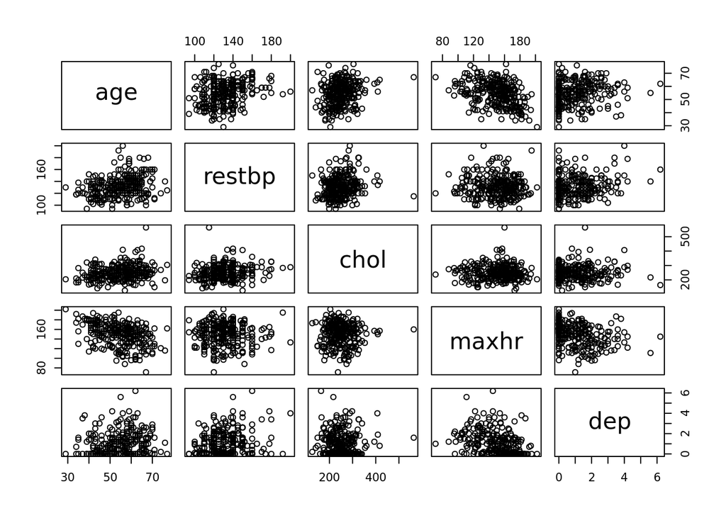

```r
> par(mfrow=c(3,3))
> rv = c("age", "restbp", "chol", "maxhr", "dep")
> for (i in 1:5) {hist(heart[,i], main = paste("Histogram of ", rv[i]), col = 'black', xlab = rv[i])}
> pairs(heart[,rv])
```

```r
> cor(heart[,rv])
```

```
              age      restbp        chol       maxhr         dep
age     1.0000000  0.27305280  0.22005631 -0.40221545  0.19423394
restbp  0.2730528  1.00000000  0.17301918 -0.03913566  0.22279983
chol    0.2200563  0.17301918  1.00000000 -0.01873919  0.02770915
maxhr  -0.4022154 -0.03913566 -0.01873919  1.00000000 -0.34904540
dep     0.1942339  0.22279983  0.02770915 -0.34904540  1.00000000
```

Based on previous data exploration and modelling, we are aware of the some of the variables that are significant in our model. Additionally, from the correlation matrix and plots, we see lack of issues that could arise due to co-linear variables.

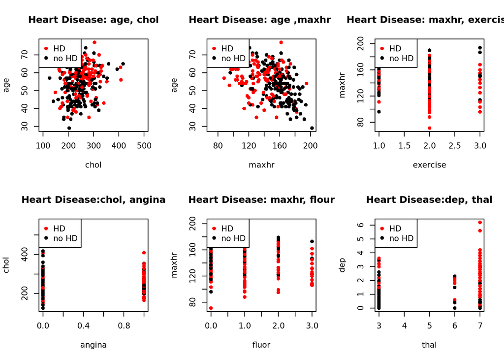

```r
> par(mfrow=c(2,3))
>
> plot(age~chol, col = output , xlim = c(100,500), pch = 16, main = "Heart Disease: age, chol")
> legend("topleft", legend=c("HD", "no HD"), pch=16, col=output)
>
>
> plot(age~maxhr, col = output, pch = 16, main = "Heart Disease: age ,maxhr ")
> legend("topleft", legend=c("HD", "no HD"), pch=16, col=output)
>
> plot(maxhr~exercise, col = output, pch = 16, main = "Heart Disease: maxhr, exercise")
> legend("topleft", legend=c("HD", "no HD"), pch=16, col=output)
>
> plot(chol~angina, col = output, pch = 16, main = "Heart Disease:chol, angina")
> legend("topleft", legend=c("HD", "no HD"), pch=16, col=output)
>
> plot(maxhr~fluor, col = output, pch = 16, main = "Heart Disease: maxhr, flour")
> legend("topleft", legend=c("HD", "no HD"), pch=16, col=output)
>
> plot(dep~thal, col = output, pch = 16, main = "Heart Disease:dep, thal")
> legend("topleft", legend=c("HD", "no HD"), pch=16, col=output)
```

Reading top to bottom, and left to right : based on the second, fourth, and sixth plots, we can see potentially good purity levels. This will be influential in our selection criteria in our classification tree.

### Building a classification tree

From the data exploration, and the information from the previous report, the strongest model obtained will be used to build the intial classification tree. This model is : output ~ fluor + thal + chestpain + dep + maxhr + sex + angina + exercise + restbp.

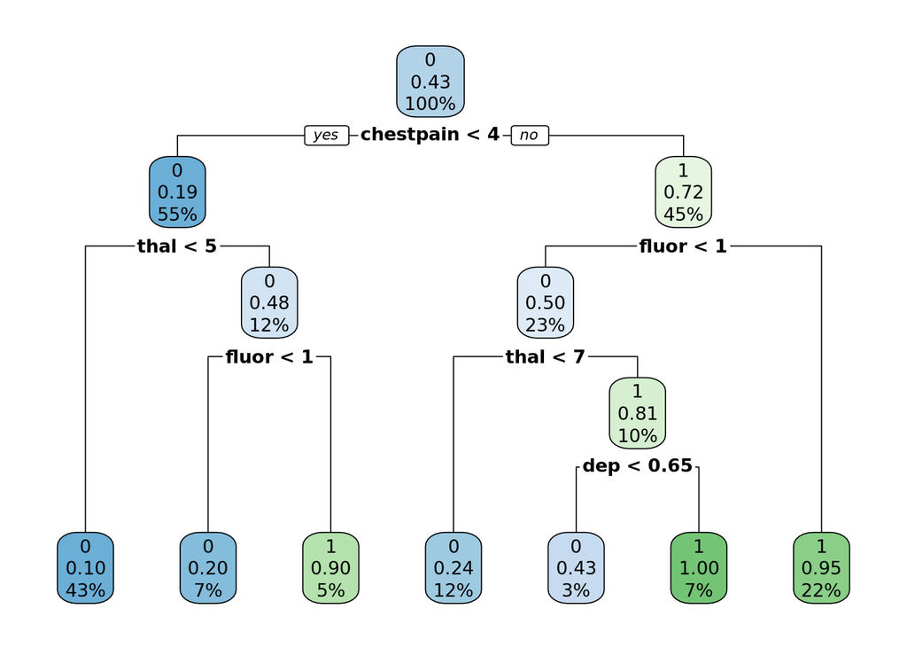

```r
> # training and test sets
> set.seed(132)
> split = split_data(heart)
> tr_dat = split[[1]]
> te_dat = split[[2]]
>
> fit1 = glm(output ~ fluor + thal + chestpain + dep + maxhr + sex + angina + exercise + restbp, data=tr_dat, family=binomial(link="logit"))
>
>
> tree1 = rpart(fit1)
> rpart.plot(tree1)
```

From this tree, it seems one of the most useful filtering criterion is “thal”, since the bottom three nodes with a prediction of heart disease is predicting with probabilities close to 1. The areas of concern lie in the lack of confidence in nodes where probabilities are close to .5, or are less saturated in color, indicated not enough filtering. This shows good ability to classify extreme cases, but there still exists those who are at risk, and not correctly classified.

```r
> gini_index = function(prob) {
+
+
+
+   gini = 2 * prob * (1 - prob)
+
+   return(gini)
+
+ }
>
> gini = gini_index(as.numeric(as.data.frame(tree1[[1]]$yval2)[,6]))
> gini
```

```
 [1] 0.00000000 0.49454221 0.48959184 0.21781639 0.13811539 0.09455212
 [7] 0.49454221 0.35296156 0.21781639 0.18712408 0.06722606 0.12960075
[13] 0.34197173
```

```r
> mean(gini)
```

```
[1] 0.2481431
```

The values of our gini index fair moderately successful but could be improved.

### Classifying test data

```r
> y = predict(tree1, te_dat)[,2]
> ytrain = predict(tree1, tr_dat)[,2]
>
>
> summary(y)
```

```
   Min. 1st Qu.  Median    Mean 3rd Qu.    Max.
 0.1047  0.2000  0.4286  0.5599  0.9545  1.0000
```

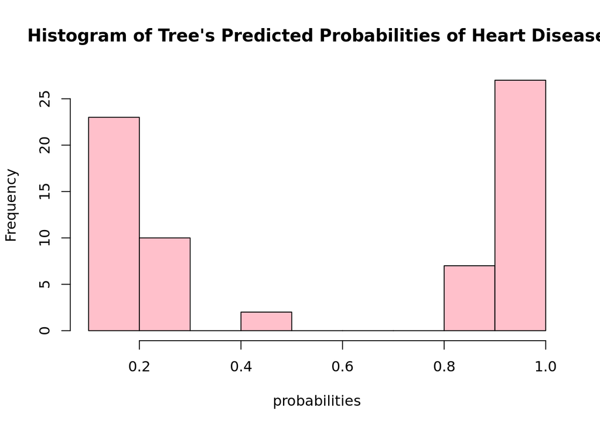

```r
> hist(y, main = "Histogram of Tree's Predicted Probabilities of Heart Disease", col = 'pink', xlab = "probabilities")
```

We can see our tree is classifying with high probabilities to belonging to the binary outcomes. This indicates a high level of confidence. We must now test whether this is founded.

### Assessing the model

```r
> predicts_tr = as.numeric(ytrain > 0.5)
> actuals_tr = tr_dat$output
> conf_mtxtr = table(predicts_tr, actuals_tr)
>
> conf_mtxtr
```

```
           actuals_tr
predicts_tr   0   1
          0 112  21
          1   3  65
```

```r
> mean(actuals_tr == predicts_tr) #accuracy
```

```
[1] 0.880597
```

```r
> predicts = as.numeric(y > 0.5)
> actuals = te_dat$output
> conf_mtx = table(predicts, actuals)
>
> conf_mtx
```

```
        actuals
predicts  0  1
       0 29  6
       1  6 28
```

```r
> mean(actuals == predicts) #accuracy
```

```
[1] 0.826087
```

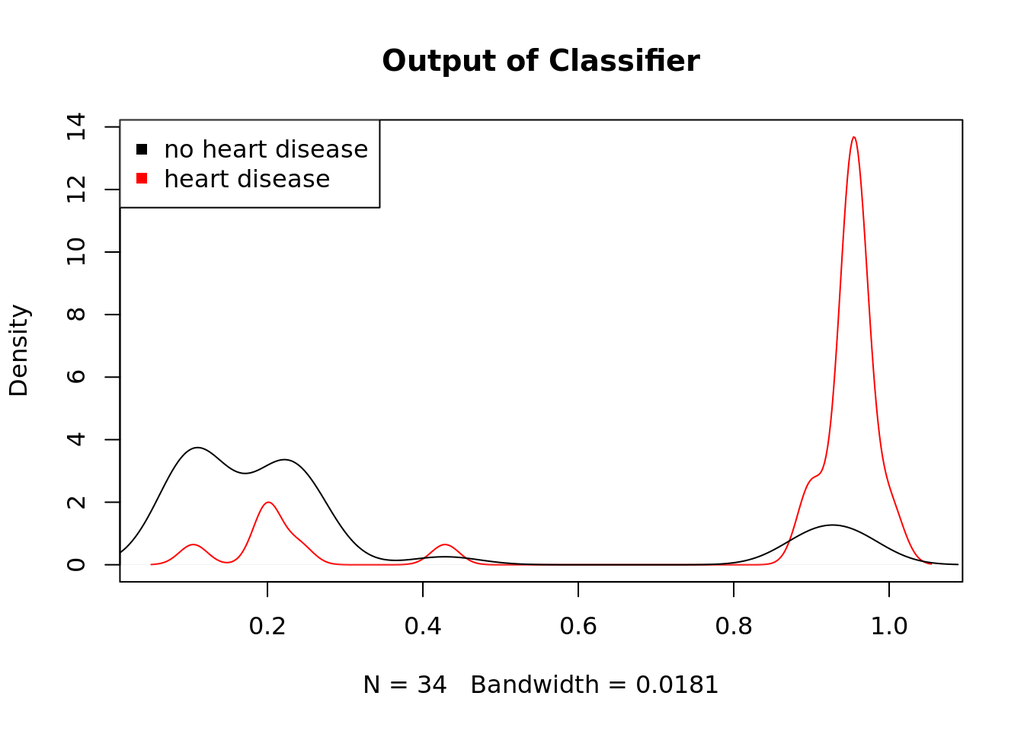

```r
> plot(density(y[actuals == 1]), col = 'red', main = "Output of Classifier")
> lines(density(y[actuals == 0]))
> legend("topleft", legend=c("no heart disease", "heart disease"), pch=15, col=c('black', 'red'))
```

This density plot indicates our threshold classification is approximately correct. After also trying different threshold levels, there is no appreciable increase in accuracy. There is however, the issue of higher potentials for false positives and false negatives in future test data.

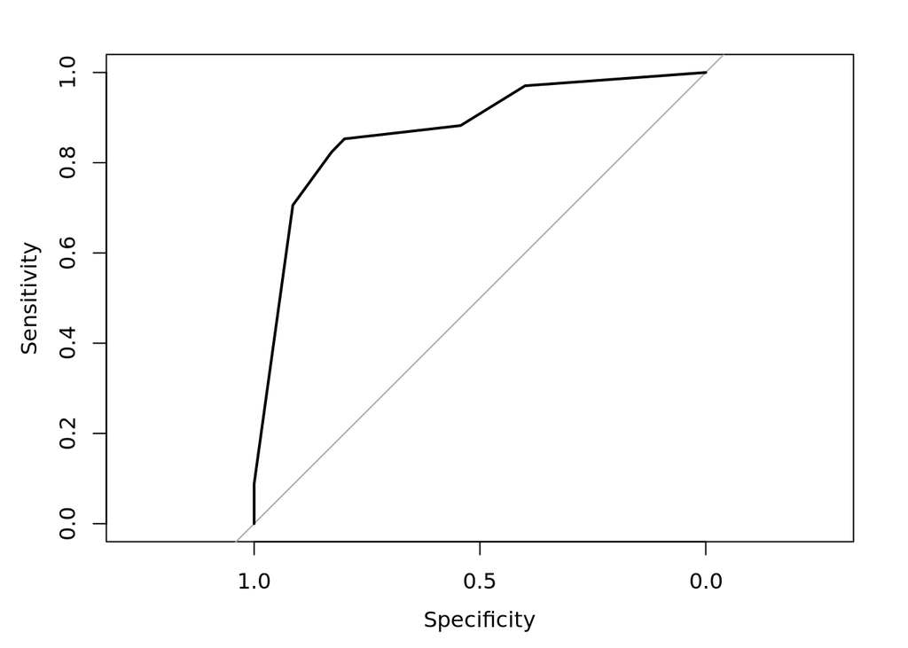

```r
> plot(roc(actuals~y))
```

```r
> auc(roc(actuals~y))
```

```
Area under the curve: 0.8731
```

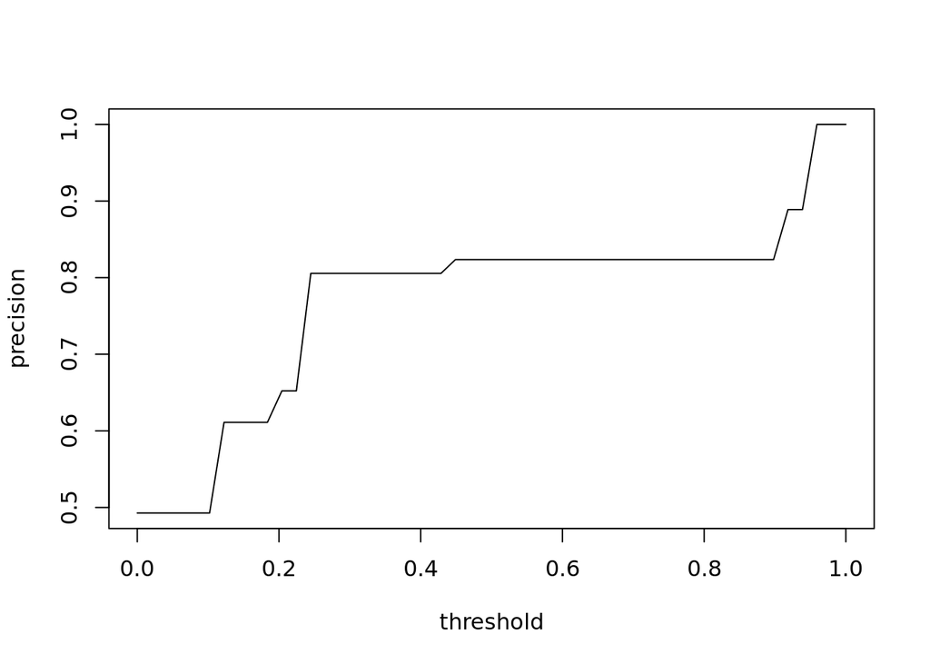

```r
> prec_recall_summary = function(predicts, actuals) {
+    thresh = seq(0, 1, length.out=50)
+    prec_rec = data.frame()
+    actuals = factor(as.numeric(actuals))
+    for (th in thresh) {
+      predicts = factor(as.numeric(y >= th), levels=c("0","1"))
+      prec_rec = rbind(prec_rec, as.vector(table(predicts, actuals)))
+    }
+    names(prec_rec) = c("TN", "FP", "FN", "TP")
+    prec_rec$threshold = thresh
+   prec_rec$precision = prec_rec$TP/(prec_rec$TP + prec_rec$FP)
+    prec_rec$recall    = prec_rec$TP/(prec_rec$TP + prec_rec$FN)
+    prec_rec$false_pos = prec_rec$FP/(prec_rec$FP + prec_rec$TN)
+    return(prec_rec)
+ }
>
> pr1 = prec_recall_summary(predicts, actuals)
> attach(pr1)
> plot(precision~threshold, type = 'l')
```

Our precision increases as we increase our threshold, but this precision vs threshold graph shows no appreciable increase increasing from .5 through values up to .85. We do however, lose accuracy going to extreme.

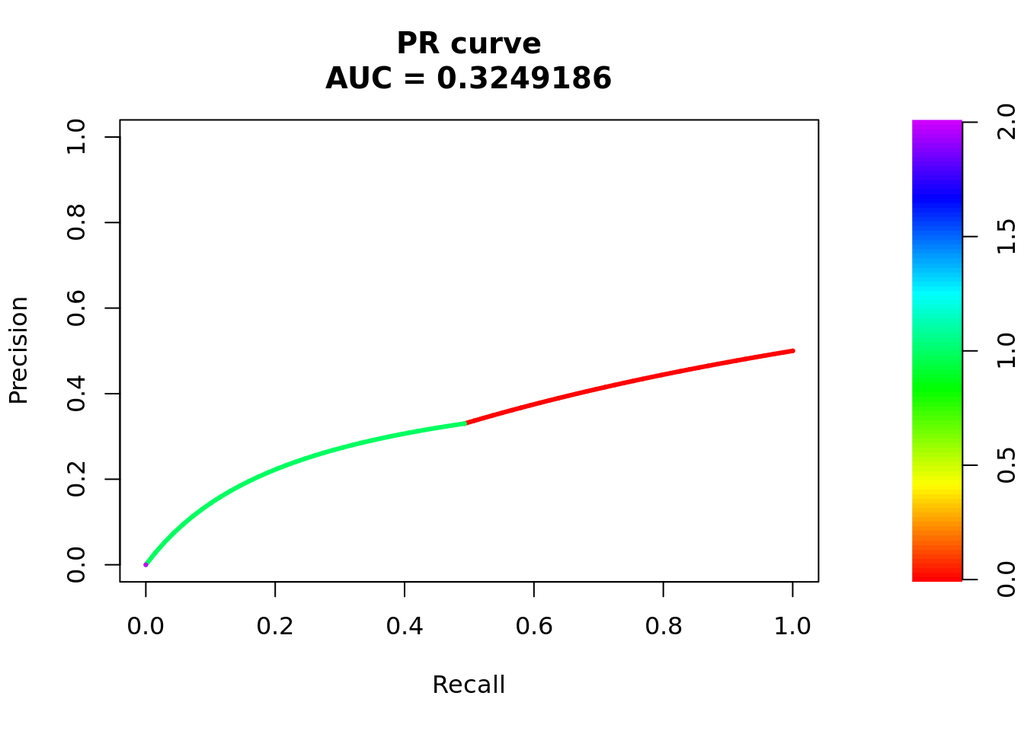

```r
> plot(pr.curve(predicts, actuals, curve = TRUE))
```

### Model 2

Knowing that our model with be based on a classification tree, the following model was based on the seemingly significant predictors from the previous tree “dep”, “fluor”, and “thal”, as well as the scatter-plots from the data exploration stage that showed the predictors that had promise to produce high purity - these predictors included “age”, “maxhr”, “chol”, “angina”.

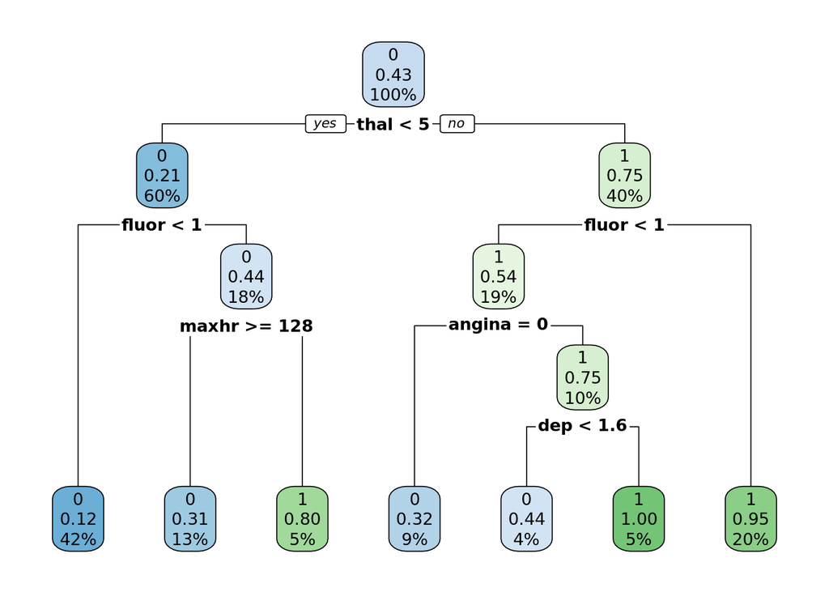

```r
> fit2 = glm(output~maxhr+angina+chol+age+fluor+dep+thal,data=tr_dat, family=binomial(link="logit"))
>
> tree2 = rpart(fit2)
> rpart.plot(tree2)
```

This tree shows similar trends as the previous one, and actuall has less confidence in nodes. Overall this model performs worse and was not useful in mitigating the concerns of the inital model.

```r
> y2 = predict(tree2, te_dat)[,2]
> ytrain2 = predict(tree2, tr_dat)[,2]
>
>
> predicts_tr2 = as.numeric(ytrain2 > 0.4)
> actuals_tr2 = tr_dat$output
> conf_mtxtr2 = table(predicts_tr2, actuals_tr2)
>
> conf_mtxtr2
```

```
            actuals_tr2
predicts_tr2   0   1
           0 106  24
           1   9  62
```

```r
> mean(actuals_tr2 == predicts_tr2) #accuracy
```

```
[1] 0.8358209
```

```r
> predicts2 = as.numeric(y2 > 0.42)
> actuals2 = te_dat$output
> conf_mtx2 = table(predicts2, actuals2)
>
> conf_mtx2
```

```
         actuals2
predicts2  0  1
        0 30  8
        1  5 26
```

```r
> mean(actuals2 == predicts2) #accuracy
```

```
[1] 0.8115942
```

```r
> gini = gini_index(as.numeric(as.data.frame(tree2[[1]]$yval2)[,6]))
> gini
```

```
 [1] 0.00000000 0.47919606 0.48810673 0.29405213 0.22524195 0.09455212
 [7] 0.47919606 0.31276454 0.17118388 0.17920349 0.08554244 0.10346279
[13] 0.32474444
```

```r
> mean(gini)
```

```
[1] 0.249019
```

There appears no appreciable improvement in the gini index.

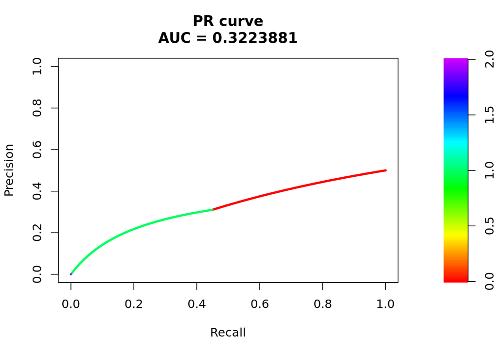

```r
> plot(pr.curve(predicts2, actuals2, curve = TRUE))
```

The PR curve plot seems to allow us to conclude the threshold for heart disease classification can be lowered in this model.

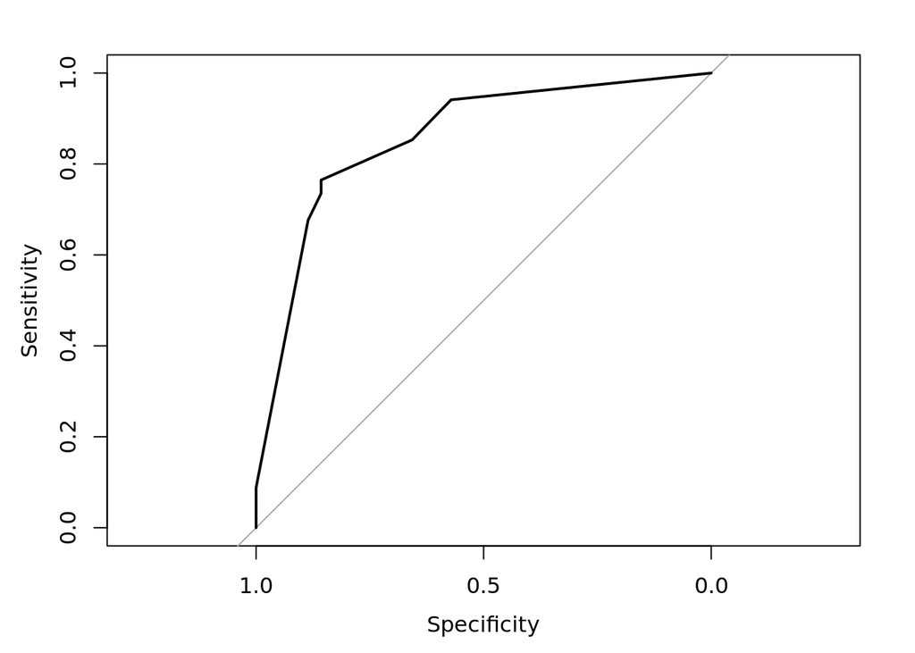

```r
> plot(roc(actuals~y2))
```

```r
> auc(roc(actuals~y2))
```

```
Area under the curve: 0.8571
```

## Model 3

The motivations for the final model is to test if the strongest model yet achieved in logistic regression, would also produce the best fit for the classification tree. This model was the third model in the example provided in homework 12.

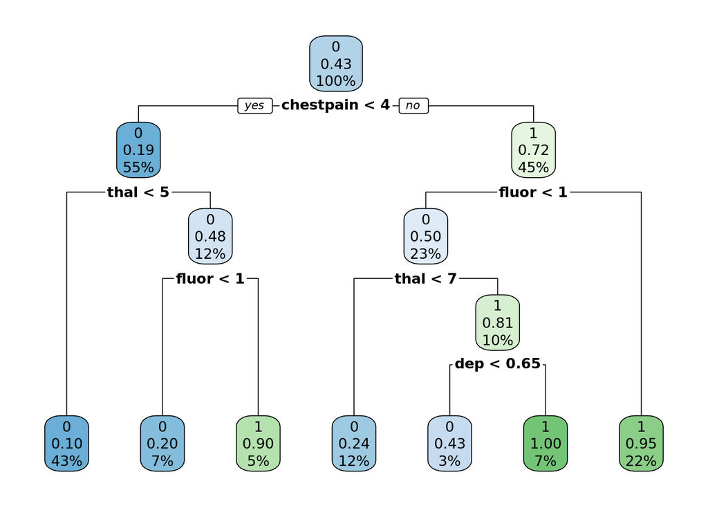

```r
> fit3 = glm(output ~ sex + chestpain + maxhr + dep + fluor + thal, data=tr_dat, family=binomial)
>
> tree3 = rpart(fit3)
> rpart.plot(tree3)
```

```r
> y3 = predict(tree3, te_dat)[,2]
> ytrain3 = predict(tree3, tr_dat)[,2]
>
>
> predicts_tr3 = as.numeric(ytrain3 > 0.5)
> actuals_tr3 = tr_dat$output
> conf_mtxtr3 = table(predicts_tr3, actuals_tr3)
>
> conf_mtxtr3
```

```
            actuals_tr3
predicts_tr3   0   1
           0 112  21
           1   3  65
```

```r
> mean(actuals_tr3 == predicts_tr3) #accuracy
```

```
[1] 0.880597
```

```r
> predicts3 = as.numeric(y3 > 0.5)
> actuals3 = te_dat$output
> conf_mtx3 = table(predicts3, actuals3)
>
> conf_mtx3
```

```
         actuals3
predicts3  0  1
        0 29  6
        1  6 28
```

```r
> mean(actuals3 == predicts3) #accuracy
```

```
[1] 0.826087
```

The model that generated this classification tree performs similarly to the previous trees. This indicates that changing the initial model is not neccessary, but changing the tree filtering criteria would be beneficial perhaps. Especially on the second, fourth, and fifth nodes, from the bottom (reading left to right).

```r
> gini = gini_index(as.numeric(as.data.frame(tree3[[1]]$yval2)[,6]))
> gini
```

```
 [1] 0.00000000 0.49454221 0.48959184 0.21781639 0.13811539 0.09455212
 [7] 0.49454221 0.35296156 0.21781639 0.18712408 0.06722606 0.12960075
[13] 0.34197173
```

```r
> mean(gini)
```

```
[1] 0.2481431
```